# Trabajo final GRUPO 9

Indicaciones:

1. Utilizando scipy. stats, crea un programa que modele la probabilidad de obtener un

número específico de éxitos en una serie de lanzamientos de una moneda sin trucos (probabilidad de éxito p = 0. 5). Genera la probabilidad de obtener exactamente 7 caras en 10 lanzamientos

```python
import math
import statistics
import numpy as np
from scipy import stats
import scipy
import pandas as pd
import matplotlib.pyplot as plt
from scipy.stats import binom
!pip install openpyxl
n = 10 #Numero de lanzamientos
p = 0.5 #Probabilidad de éxito

#Probabiidad de obtener exactamente 7 caras
#en una serie de lanzamientos de una moneda sin trucos

prob_cara_7 = binom.pmf(7, n, p)
print(f"La probabilidad de obtener exactamente 7 caras es:", round(prob_cara_7,4))
```

```
La probabilidad de obtener exactamente 7 caras es: 0.1172
```

Calcula la probabilidad acumulada de obtener 7 o menos caras en 10 lanzamientos

```python
prob_acumulada_cara_7 = binom.cdf(7, n, p)
print(f"La probabilidad acumulada de obtener 7 o menos caras es :", round(prob_acumulada_cara_7,4))
```

```
La probabilidad acumulada de obtener 7 o menos caras es : 0.9453
```

Grafica la distribución binomial completa para los 10 lanzamientos, mostrando la probabilidad de obtener desde 0 hasta 10 caras.

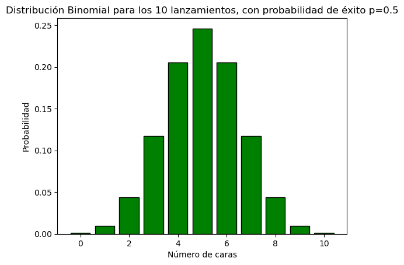

```python
#Los valores de éxitos posibles (de 0 a 10)
x = np.arange(0, n+1)

#Las probabiidades de cada número de éxitos
probs_x = binom.pmf(x, n, p)
#El gráfico
plt.bar(x, probs_x, color = "green", edgecolor = "black")
plt.xlabel("Número de caras")
plt.ylabel("Probabilidad")
plt.title("Distribución Binomial para los 10 lanzamientos, con probabilidad de éxito p=0.5")
plt.show()
```

Ahora la moneda tiene mayor probabilidad de caer en cara (probabilidad de éxito p = 0. 8). ¿Cómo cambian los resultados? Vuelve a realizar los ejercicios I, II y III.

```python
#Ahora la probabilidad cambió
p = 0.8
#Primer ejercicio con p=0.8
nuevo_prob_cara_7 = binom.pmf(7, n,p)
print(f"La nueva probabilidad de obtener exactamente 7 caras es:", round(nuevo_prob_cara_7,4))
```

```
La nueva probabilidad de obtener exactamente 7 caras es: 0.2013
```

```python
#Segundo ejercicio con p=0.8
nuevo_prob_acumulada_cara_7 = binom.cdf(7,n, p)
print(f"La nueva probabilidad acumulada de obtener 7 o menos cara es:", round(nuevo_prob_acumulada_cara_7,4))
```

```
La nueva probabilidad acumulada de obtener 7 o menos cara es: 0.3222
```

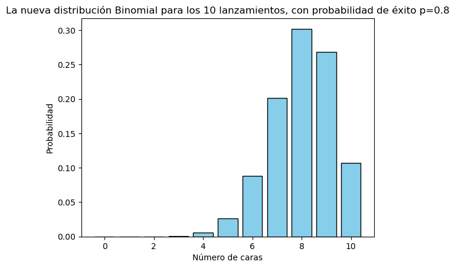

```python
#Tercer ejercicio
#Los valores de éxitos posibles (de 0 a 10)
x = np.arange(0, n+1)

#Las nuevas probabiidades de cada número de éxitos
probs_x = binom.pmf(x, n, p)
#El gráfico
plt.bar(x, probs_x, color = "skyblue", edgecolor = "black")
plt.xlabel("Número de caras")
plt.ylabel("Probabilidad")
plt.title("La nueva distribución Binomial para los 10 lanzamientos, con probabilidad de éxito p=0.8")
plt.show()
```

Utilizando scipy. stats, realiza un análisis de una distribución normal con una media de 0 y desviación estándar de 1. Genera un conjunto de datos aleatorios con 1000 muestras a partir de esta distribución.

```python
#Los parámetros de la distrbución normal
media = 0
desviacion_estandar = 1
numero_muestras = 1000

#Toca generar el conjunto de datos con 1000 muestras a partir de la distirbución
datos = np.random.normal(media, desviacion_estandar, numero_muestras)
```

Calcula y muestra la media, la desviación estándar y la mediana de los datos generados.

```python
media_datos = np.mean(datos)
desviacion_datos = np.std(datos, ddof=1)
mediana_datos = np.median(datos)

print(f"La media de los datos generados es:", round(media_datos,4))
print(f"La desviación estándar de los datos generados es:", round(desviacion_datos,4))
print(f"La mediana de los datos generados es:", round(mediana_datos,4))
```

```
La media de los datos generados es: -0.0072
La desviación estándar de los datos generados es: 0.9477
La mediana de los datos generados es: 0.0221
```

Grafica el histograma de los datos y superpón la curva de la distribución normal teórica.

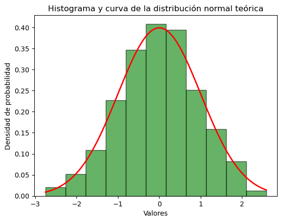

```python
from scipy.stats import norm
#El histograma de los datos
plt.hist(datos, bins=11, density=True, alpha=0.6, color = "g", edgecolor= "black")

#Curva de la distribución normal teórica
x = np.linspace(min(datos), max(datos), 100)
y = norm.pdf(x, media, desviacion_estandar)
plt.plot(x, y, "r", linewidth = 2)

plt.xlabel("Valores")
plt.ylabel("Densidad de probabilidad")
plt.title("Histograma y curva de la distribución normal teórica")

plt.show()
```

Calcula la probabilidad de que un valor caiga dentro del rango de -1 a 1 (una desviación estándar de la media).

```python
prob_ejercicio = norm.cdf(1, media, desviacion_estandar) - norm.cdf(-1, media, desviacion_estandar)
print(f"La probabilidad de que el valor caiga dentro del rango de -1 a 1 es:", round(prob_ejercicio,4))
```

```
La probabilidad de que el valor caiga dentro del rango de -1 a 1 es: 0.6827
```

# Parte 2

Contaran con toda la información sobre el trabajo en la carpeta "Trabajo Final" del Github de curso. Lean con cuidado las indicaciones. Algunos puntos a tener en cuenta:

Puedes elegir una de estas dos opciones

- Indicadores de Desarrollo GlobaL, a nivel país.
- El IDH, a nivel distrital, provincial o departamental.

Realiza 4 gráficos con la base de datos de tu elección. Ojo que cualquiera de las opciones implica realizar alguna limpieza de los datos.

Aquí van algunas ideas:

Para los indicadores de desarrollo global:

- puedes ver la evolución en el tiempo de un sólo indicador, para un sólo pais, o región.
- Puedes hacer la comparación entre la evolucion de varios países.
- puedes ver la comparación entre países de un sólo indicador. Puedes enfocarte en una o varias regiones.
- puedes ver la relación de dos o más indicadores.

Para el IDH:

- puedes ver la comparación de alguno de los indicadores entre distritos dentro de un departamento.
- puedes ver la relación de dos indicadores que componen el IDH, entre ellos.

Hay más opciones de temas para los indicadores de desarrollo global.

Formato de entrega: Un archivo txt con la URL de la web en Github o notebook del trabajo que también incluya la URL de la web en github. Tener en consideración que dado que el trabajo es de grupos de 5 solo sera necesario que este publicado en un Github. Además dentro de la pagina de Github del trabajo final esta un tutorial de como publicar sus paginas en formato html.

```python
df_IDH =pd.read_excel("IDH_PNUD_2017.xlsx", sheet_name="Departamental", header=2)
def limpiar_datos(archivo):
    #Primero eliminamos las columnas cuyo título está vacío
    archivo = archivo.drop(columns=[col for col in archivo.columns if "Unnamed" in col])
    #Luego se borran las primeras 4 y últimas 3 filas sin datos
    archivo = archivo.iloc[4:].reset_index(drop=True)
    archivo = archivo.iloc[:-3].reset_index(drop=True)
    return archivo #Retorna el archivo limpio
df_IDH_final = limpiar_datos(df_IDH)
df_IDH_final
```

|  | UBIGEO | DEPARTAMENTO | Población | Índice de Desarrollo Humano | Esperanza de vida al nacer | Con Educación secundaria completa (Poblac. 18 años) | Años de educación (Poblac. 25 y más) | Ingreso familiar per cápita |
| --- | --- | --- | --- | --- | --- | --- | --- | --- |
| 0 | 000000 | PERÚ | 29381884 | 0.572345 | 75.52714 | 67.108865 | 8.78599 | 990.116633 |
| 1 | 010000 | AMAZONAS | 379384 | 0.417452 | 73.306564 | 46.859333 | 6.050521 | 629.7113 |
| 2 | 020000 | ANCASH | 1083519 | 0.488391 | 75.743889 | 61.110602 | 7.633381 | 712.6623 |
| 3 | 030000 | APURÍMAC | 405759 | 0.416742 | 72.634854 | 65.547677 | 6.610242 | 511.8983 |
| 4 | 040000 | AREQUIPA | 1382730 | 0.634479 | 78.203421 | 77.80172 | 10.097563 | 1088.0636 |
| 5 | 050000 | AYACUCHO | 616176 | 0.409602 | 71.078435 | 59.357975 | 6.905559 | 512.4642 |
| 6 | 060000 | CAJAMARCA | 1341012 | 0.40106 | 74.746021 | 51.376462 | 5.607542 | 551.7471 |
| 7 | 070100 | Provincia Constitucional del CALLAO | 994494 | 0.666302 | 82.515232 | 73.497518 | 10.062423 | 1198.1964 |
| 8 | 080000 | CUSCO | 1205527 | 0.470121 | 70.740178 | 66.690447 | 7.798155 | 667.9998 |
| 9 | 090000 | HUANCAVELICA | 347639 | 0.335663 | 64.034012 | 56.184207 | 5.735151 | 398.1561 |
| 10 | 100000 | HUÁNUCO | 721047 | 0.428468 | 73.110342 | 53.614801 | 6.572781 | 604.6419 |
| 11 | 110000 | ICA | 850765 | 0.612103 | 81.663418 | 73.527836 | 9.905355 | 958.9974 |
| 12 | 120000 | JUNÍN | 1246038 | 0.495384 | 73.181276 | 65.8842 | 8.381481 | 710.3179 |
| 13 | 130000 | LA LIBERTAD | 1778080 | 0.538779 | 77.214338 | 60.848472 | 8.033712 | 892.1488 |
| 14 | 140000 | LAMBAYEQUE | 1197260 | 0.53949 | 77.288576 | 67.090434 | 8.445149 | 827.6347 |
| 15 | 150000 | LIMA | 9485405 | 0.715651 | 81.153518 | 75.707688 | 10.35686 | 1464.2608 |
| 16 | 160000 | LORETO | 883510 | 0.454914 | 71.419194 | 45.044803 | 7.560003 | 736.7302 |
| 17 | 170000 | MADRE DE DIOS | 141070 | 0.56188 | 73.718619 | 63.758325 | 8.726031 | 1000.6915 |
| 18 | 180000 | MOQUEGUA | 174863 | 0.638726 | 79.800886 | 74.491285 | 9.921653 | 1112.4407 |
| 19 | 190000 | PASCO | 254065 | 0.460667 | 72.040411 | 68.253589 | 8.141167 | 591.7423 |
| 20 | 200000 | PIURA | 1856809 | 0.479728 | 73.696331 | 61.930024 | 7.577943 | 702.9804 |
| 21 | 210000 | PUNO | 1172697 | 0.427841 | 68.475641 | 72.150998 | 7.447559 | 532.3485 |
| 22 | 220000 | SAN MARTÍN | 813381 | 0.467982 | 73.718529 | 52.462043 | 6.644659 | 770.4451 |
| 23 | 230000 | TACNA | 329332 | 0.606991 | 77.53434 | 74.913182 | 9.810744 | 1003.4997 |
| 24 | 240000 | TUMBES | 224863 | 0.559666 | 79.057924 | 66.70287 | 8.666748 | 879.4833 |
| 25 | 250000 | UCAYALI | 496459 | 0.470985 | 72.861223 | 51.943499 | 8.052112 | 710.1024 |

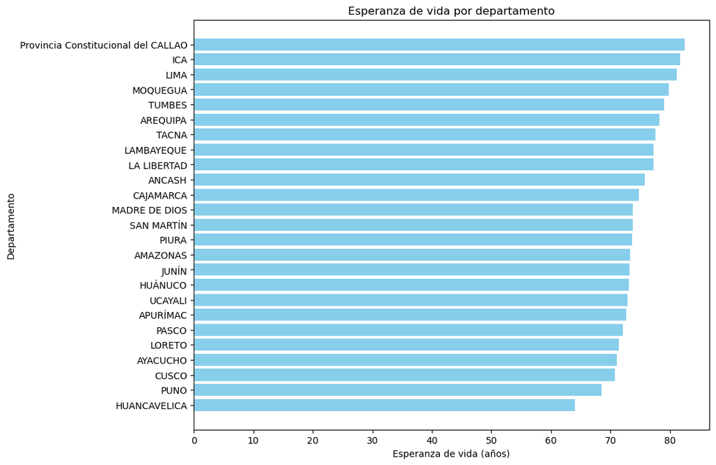

```python
#Gráfico 1
df_IDH_final = df_IDH_final.iloc[1:]
df_IDH_sorted_1 = df_IDH_final.sort_values("Esperanza de vida al nacer", ascending=True)

plt.figure(figsize=(10,8))
plt.barh(df_IDH_sorted_1["DEPARTAMENTO"], df_IDH_sorted_1["Esperanza de vida al nacer"], color="skyblue")

plt.xlabel("Esperanza de vida (años)")
plt.ylabel("Departamento")
plt.title("Esperanza de vida por departamento")

plt.show()
```

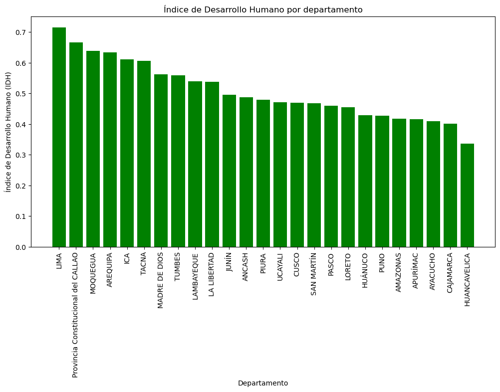

```python
#Gráfico 2
df_IDH_sorted_2 = df_IDH_final.sort_values("Índice de Desarrollo Humano", ascending=False)

plt.figure(figsize=(12,6))
plt.bar(df_IDH_sorted_2["DEPARTAMENTO"], df_IDH_sorted_2["Índice de Desarrollo Humano"], color="green")

plt.xticks(rotation=90)
plt.xlabel("Departamento")
plt.ylabel("Índice de Desarrollo Humano (IDH)")
plt.title("Índice de Desarrollo Humano por departamento")

plt.show()
```

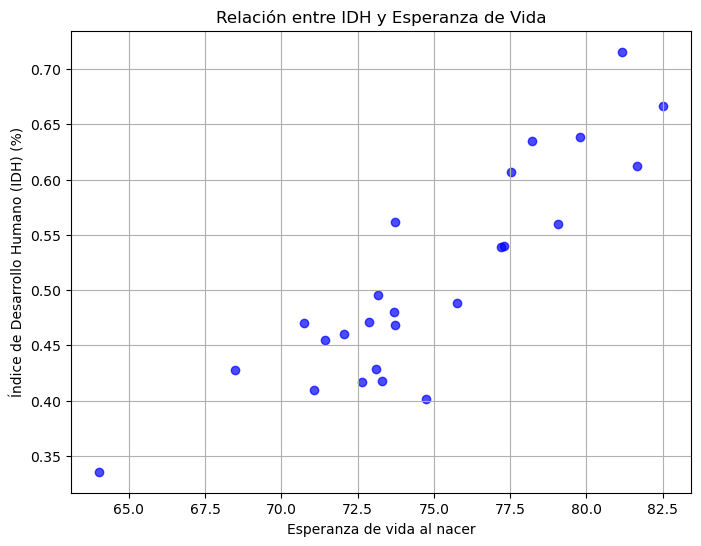

```python
#Gráfico 3
plt.figure(figsize=(8,6))
plt.scatter(df_IDH_final["Esperanza de vida al nacer"], df_IDH_final["Índice de Desarrollo Humano"], color="blue", alpha=0.7)
plt.xlabel("Esperanza de vida al nacer")
plt.ylabel("Índice de Desarrollo Humano (IDH) (%)")
plt.title("Relación entre IDH y Esperanza de Vida")
plt.grid(True)
plt.show()
```

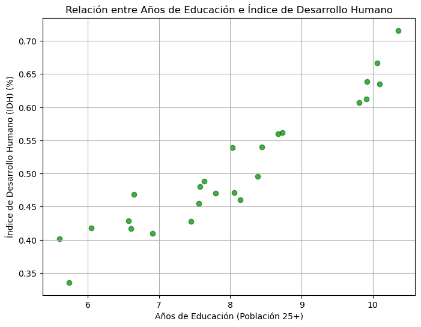

```python
#Gráfico 4
plt.figure(figsize=(8,6))
plt.scatter(df_IDH_final["Años de educación (Poblac. 25 y más)"], df_IDH_final["Índice de Desarrollo Humano"], color="green", alpha=0.7)
plt.xlabel("Años de Educación (Población 25+)")
plt.ylabel("Índice de Desarrollo Humano (IDH) (%)")
plt.title("Relación entre Años de Educación e Índice de Desarrollo Humano")
plt.grid(True)
plt.show()
```

## Ha sido un gusto poder enseñarles . Hasta pronto :D

(╯°□°）╯︵ ┻━┻